# Weir Inflow Data collation and Plots for EDI

2023-02-15

Master QAQC script in prep for publishing FCR inflow data to EDI. This script uses the qaqcfcr_weir function, which automatically QAQCs the data, and produces figures to look over the data and visually inspect for major outliers.

Use this file path in Carey Lab Reservoir GitHub Repo: “./Data/DataAlreadyUploadedToEDI/EDIProductionFiles/MakeEML_Inflow/2023_Jan/”

This step gets the right packages and sources the QAQC script. Make sure you have the correct year for the script file (e.g., don’t use 2023_Jan if it’s no longer 2023).

# Check for gaps in the data frame

This identifies if there are any daily data gaps in the long-term record.

### Daily Gaps for VT Sensors

This identifies if there are any sub-daily gaps in the long-term record. Most of these gaps happen when we change the program on the data logger.

### Sub-daily Gaps in VT Sensors

```
## [1] "2021-11-22 14:15:00 UTC" "2021-11-22 14:30:00 UTC"
## [1] "2022-11-16 15:45:00 UTC" "2022-11-16 17:00:00 UTC"
```

### Daily Gaps in WVWA sensors

```
## [1] "2016-10-31 16:00:00 UTC" "2016-11-02 10:45:00 UTC"
## [1] "2016-11-22 20:00:00 UTC" "2016-11-24 09:30:00 UTC"
## [1] "2016-11-29 20:00:00 UTC" "2016-12-01 09:45:00 UTC"
## [1] "2016-12-03 14:00:00 UTC" "2016-12-05 10:45:00 UTC"
## [1] "2016-12-05 23:00:00 UTC" "2016-12-07 09:30:00 UTC"
## [1] "2016-12-07 21:45:00 UTC" "2016-12-09 09:45:00 UTC"
## [1] "2016-12-17 19:30:00 UTC" "2016-12-19 13:45:00 UTC"
## [1] "2016-12-23 14:45:00 UTC" "2016-12-27 13:15:00 UTC"
## [1] "2017-01-01 15:45:00 UTC" "2017-01-04 12:45:00 UTC"
## [1] "2017-01-05 14:45:00 UTC" "2017-01-07 14:00:00 UTC"
## [1] "2017-01-14 14:00:00 UTC" "2017-01-18 11:30:00 UTC"
## [1] "2017-01-21 12:00:00 UTC" "2017-01-24 10:30:00 UTC"
## [1] "2017-11-07 18:00:00 UTC" "2017-11-10 11:00:00 UTC"
## [1] "2020-05-14 16:45:00 UTC" "2020-08-24 15:00:00 UTC"
## [1] "2021-07-21 14:15:00 UTC" "2021-10-25 14:00:00 UTC"
## [1] "2021-10-26 14:45:00 UTC" "2021-11-08 14:15:00 UTC"
## [1] "2021-12-07 13:00:00 UTC" "2021-12-14 12:00:00 UTC"
## [1] "2022-06-05 22:15:00 UTC" "2022-06-27 09:45:00 UTC"
```

### Info for Rating Curves

```
## [1] "Could not parse column flagcol in row 1 of the rating log."
```

```
##    Sensor               Start                 End  Slope Intercept Low_psi
## 1    WVWA 2019-06-07 00:15:00 2020-08-24 13:00:00 63.163    -8.701   0.138
## 2      VT 2019-06-07 00:15:00 2020-08-24 13:00:00 70.640    -5.663   0.080
## 3    WVWA 2020-08-24 15:00:00 2020-09-02 13:15:00 53.191    -1.085   0.020
## 4      VT 2020-08-24 15:00:00 2020-09-02 13:15:00 58.140     2.930  -0.050
## 5    WVWA 2020-09-02 13:45:00 2021-11-08 13:45:00 69.021     0.812  -0.012
## 6      VT 2020-09-02 13:45:00 2021-11-08 13:45:00 71.993     5.801  -0.081
## 7    WVWA 2021-11-08 14:00:00 2022-05-09 13:15:00 84.521    -6.381   0.075
## 8      VT 2021-11-08 14:00:00 2022-05-09 13:15:00 84.862     1.719  -0.020
## 9      VT 2022-05-09 13:20:00 2022-11-16 16:38:00 71.610     2.413  -0.034
## 10   WVWA 2022-05-09 14:15:00 2023-12-31 23:59:00 72.510    -5.226   0.072
## 11     VT 2022-11-16 17:15:00 2023-12-31 23:59:00 71.429     1.500  -0.021
##    High_psi
## 1     0.573
## 2     0.469
## 3     0.537
## 4     0.423
## 5     0.387
## 6     0.301
## 7     0.401
## 8     0.304
## 9     0.350
## 10    0.451
## 11    0.364
```

## Read in the QAQC File and Check it out

```r
# read in qaqc function output

weirdata <- read_csv(output_file, show_col_types=F)
#fcrmetdata <- read_csv("FCR_Met_final_2015_2022.csv")

# what does the beginning look like
head(weirdata)
```

```
## # A tibble: 6 × 19
##   Reservoir  Site DateTime            WVWA_Pre…¹ WVWA_…² WVWA_…³ WVWA_…⁴ WVWA_…⁵
##   <chr>     <dbl> <dttm>                   <dbl>   <dbl>   <dbl>   <dbl>   <dbl>
## 1 FCR         100 2013-05-15 15:00:00       13.9    13.8  0.0490 NA         20.6
## 2 FCR         100 2013-05-15 15:15:00       14.1    13.8  0.238  NA         16.3
## 3 FCR         100 2013-05-15 15:30:00       14.1    13.8  0.243  NA         16.2
## 4 FCR         100 2013-05-15 15:45:00       14.1    13.8  0.244  NA         16.2
## 5 FCR         100 2013-05-15 16:00:00       14.1    13.8  0.244   0.0172    16.2
## 6 FCR         100 2013-05-15 16:15:00       14.1    13.8  0.242   0.0163    16.1
## # … with 11 more variables: VT_Pressure_psia <dbl>, VT_Flow_cms <dbl>,
## #   VT_Temp_C <dbl>, Flag_WVWA_Pressure_psi <dbl>,
## #   Flag_WVWA_Baro_pressure_psi <dbl>, Flag_WVWA_Pressure_psia <dbl>,
## #   Flag_WVWA_Flow_cms <dbl>, Flag_WVWA_Temp_C <dbl>,
## #   Flag_VT_Pressure_psia <dbl>, Flag_VT_Flow_cms <dbl>, Flag_VT_Temp_C <dbl>,
## #   and abbreviated variable names ¹WVWA_Pressure_psi, ²WVWA_Baro_pressure_psi,
## #   ³WVWA_Pressure_psia, ⁴WVWA_Flow_cms, ⁵WVWA_Temp_C
```

```r
# Make sure it goes to Dec 31st 23:59 of the previous year or your ending period
tail(weirdata)
```

```
## # A tibble: 6 × 19
##   Reservoir  Site DateTime            WVWA_Pre…¹ WVWA_…² WVWA_…³ WVWA_…⁴ WVWA_…⁵
##   <chr>     <dbl> <dttm>                   <dbl>   <dbl>   <dbl>   <dbl>   <dbl>
## 1 FCR         100 2022-12-31 22:30:00       14.1    13.9   0.217 0.00856    6.44
## 2 FCR         100 2022-12-31 22:45:00       14.1    13.9   0.226 0.00995    6.38
## 3 FCR         100 2022-12-31 23:00:00       14.1    13.9   0.232 0.0109     6.31
## 4 FCR         100 2022-12-31 23:15:00       14.1    13.9   0.231 0.0108     6.31
## 5 FCR         100 2022-12-31 23:30:00       14.1    13.9   0.233 0.0111     6.31
## 6 FCR         100 2022-12-31 23:45:00       14.1    13.9   0.230 0.0106     6.25
## # … with 11 more variables: VT_Pressure_psia <dbl>, VT_Flow_cms <dbl>,
## #   VT_Temp_C <dbl>, Flag_WVWA_Pressure_psi <dbl>,
## #   Flag_WVWA_Baro_pressure_psi <dbl>, Flag_WVWA_Pressure_psia <dbl>,
## #   Flag_WVWA_Flow_cms <dbl>, Flag_WVWA_Temp_C <dbl>,
## #   Flag_VT_Pressure_psia <dbl>, Flag_VT_Flow_cms <dbl>, Flag_VT_Temp_C <dbl>,
## #   and abbreviated variable names ¹WVWA_Pressure_psi, ²WVWA_Baro_pressure_psi,
## #   ³WVWA_Pressure_psia, ⁴WVWA_Flow_cms, ⁵WVWA_Temp_C
```

```r
# check out the structure
str(weirdata)
```

```
## spc_tbl_ [328,172 × 19] (S3: spec_tbl_df/tbl_df/tbl/data.frame)
##  $ Reservoir                  : chr [1:328172] "FCR" "FCR" "FCR" "FCR" ...
##  $ Site                       : num [1:328172] 100 100 100 100 100 100 100 100 100 100 ...
##  $ DateTime                   : POSIXct[1:328172], format: "2013-05-15 15:00:00" "2013-05-15 15:15:00" ...
##  $ WVWA_Pressure_psi          : num [1:328172] 13.9 14.1 14.1 14.1 14.1 ...
##  $ WVWA_Baro_pressure_psi     : num [1:328172] 13.8 13.8 13.8 13.8 13.8 ...
##  $ WVWA_Pressure_psia         : num [1:328172] 0.049 0.238 0.243 0.244 0.244 ...
##  $ WVWA_Flow_cms              : num [1:328172] NA NA NA NA 0.0172 ...
##  $ WVWA_Temp_C                : num [1:328172] 20.6 16.3 16.2 16.2 16.2 ...
##  $ VT_Pressure_psia           : num [1:328172] NA NA NA NA NA NA NA NA NA NA ...
##  $ VT_Flow_cms                : num [1:328172] NA NA NA NA NA NA NA NA NA NA ...
##  $ VT_Temp_C                  : num [1:328172] NA NA NA NA NA NA NA NA NA NA ...
##  $ Flag_WVWA_Pressure_psi     : num [1:328172] 0 0 0 0 0 0 0 0 0 0 ...
##  $ Flag_WVWA_Baro_pressure_psi: num [1:328172] 0 0 0 0 0 0 0 0 0 0 ...
##  $ Flag_WVWA_Pressure_psia    : num [1:328172] 0 0 0 0 0 0 0 0 0 0 ...
##  $ Flag_WVWA_Flow_cms         : num [1:328172] 7 7 7 7 0 0 0 0 0 0 ...
##  $ Flag_WVWA_Temp_C           : num [1:328172] 0 0 0 0 0 0 0 0 0 0 ...
##  $ Flag_VT_Pressure_psia      : num [1:328172] 7 7 7 7 7 7 7 7 7 7 ...
##  $ Flag_VT_Flow_cms           : num [1:328172] 7 7 7 7 7 7 7 7 7 7 ...
##  $ Flag_VT_Temp_C             : num [1:328172] 7 7 7 7 7 7 7 7 7 7 ...
##  - attr(*, "spec")=
##   .. cols(
##   ..   Reservoir = col_character(),
##   ..   Site = col_double(),
##   ..   DateTime = col_datetime(format = ""),
##   ..   WVWA_Pressure_psi = col_double(),
##   ..   WVWA_Baro_pressure_psi = col_double(),
##   ..   WVWA_Pressure_psia = col_double(),
##   ..   WVWA_Flow_cms = col_double(),
##   ..   WVWA_Temp_C = col_double(),
##   ..   VT_Pressure_psia = col_double(),
##   ..   VT_Flow_cms = col_double(),
##   ..   VT_Temp_C = col_double(),
##   ..   Flag_WVWA_Pressure_psi = col_double(),
##   ..   Flag_WVWA_Baro_pressure_psi = col_double(),
##   ..   Flag_WVWA_Pressure_psia = col_double(),
##   ..   Flag_WVWA_Flow_cms = col_double(),
##   ..   Flag_WVWA_Temp_C = col_double(),
##   ..   Flag_VT_Pressure_psia = col_double(),
##   ..   Flag_VT_Flow_cms = col_double(),
##   ..   Flag_VT_Temp_C = col_double()
##   .. )
##  - attr(*, "problems")=<externalptr>
```

## Check out the Flag frequency

Let’s look at the Flag frequency for each variable.

As a reminder here are the Flag codes:

0: no flag;

1: value corrected to account for artificial increase in pressure after sensor maintenance;

2: sensor malfunction;

3: value of NA due to extremely low flows that are not well captured by rectangular or v-notch weir;

4: demonic intrusion;

5: value of NA due to leaking at weir;

6: flow topping the v-notch weir;

7: missing observation/not recorded;

8: values removed because of maintenance;

13: value downcorrected due to low flows on the rectangular weir;

16: value downcorrected due to flow overtopping the rectangular weir;

24: sensor malfunction and demonic intrusion.

```
## Flag_WVWA_Pressure_psi
##      0      1      5      7      8     24   <NA>
## 204498  98503   2133  19631   1107   2300      0
## Flag_WVWA_Baro_pressure_psi
##      0      2      7      8     24   <NA>
## 299399   5731  19635   1107   2300      0
## Flag_WVWA_Pressure_psia
##      0      2      5      7      8     24   <NA>
## 297266   5731   2133  19635   1107   2300      0
## Flag_WVWA_Flow_cms
##      0      2      3      5      6      7      8     13     14     16     24
## 282480   5731    396   2133   3126  19775   1107  11010    112      2   2300
##   <NA>
##      0
## Flag_WVWA_Temp_C
##      0      5      7      8     24   <NA>
## 302997   2133  19635   1107   2300      0
## Flag_VT_Pressure_psia
##      0      1      2      7      8     24   <NA>
##  90079  34814   1236 198642   1101   2300      0
## Flag_VT_Flow_cms
##      0      2      4      6      7      8     24   <NA>
## 109575   1236   4417  10964 198578   1102   2300      0
## Flag_VT_Temp_C
##      0      2      7      8     24   <NA>
## 124892   1236 198642   1102   2300      0
```

## QAQC Plots

These are QAQC plots to see if there are any questionable values we missed.

## Flow

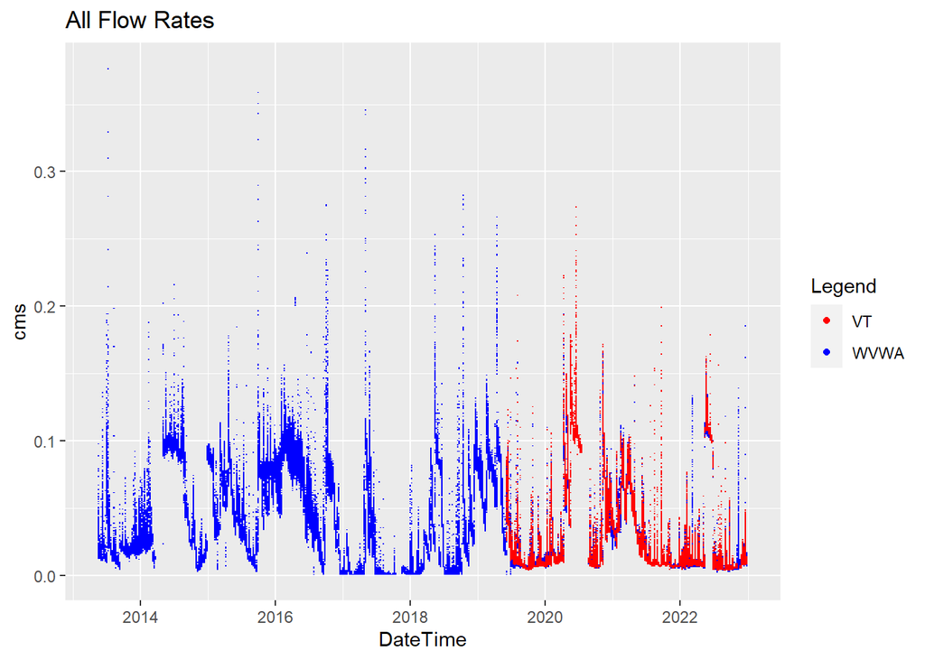

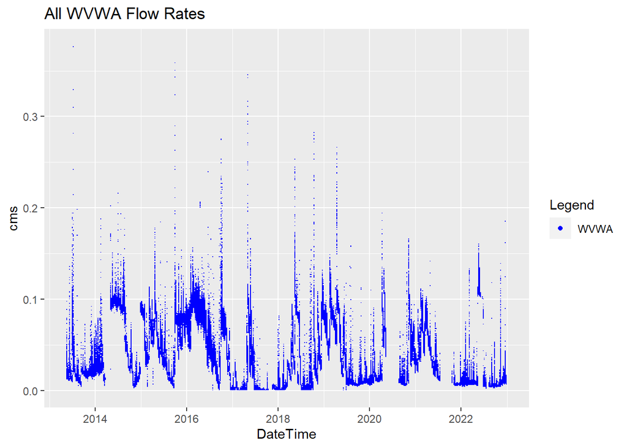

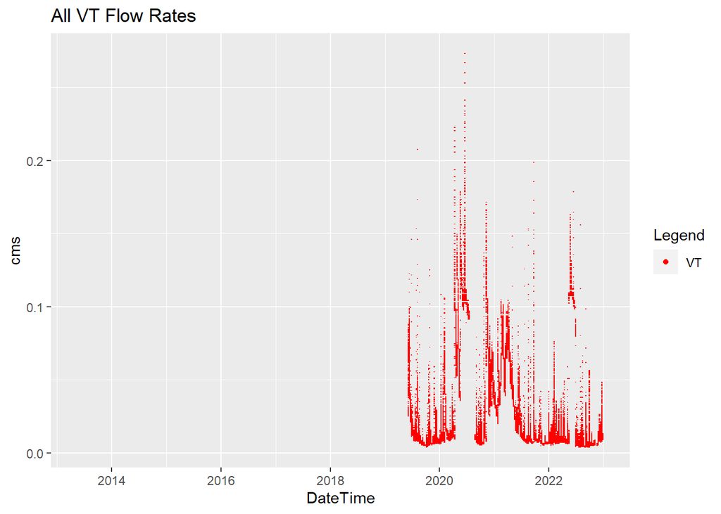

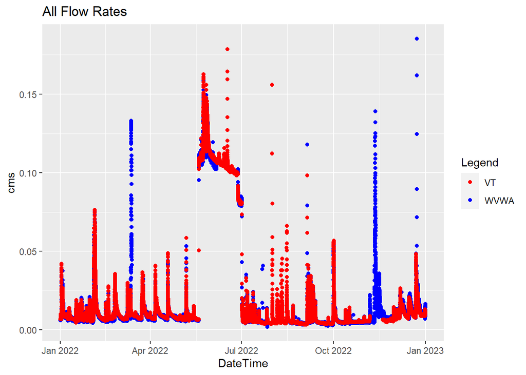

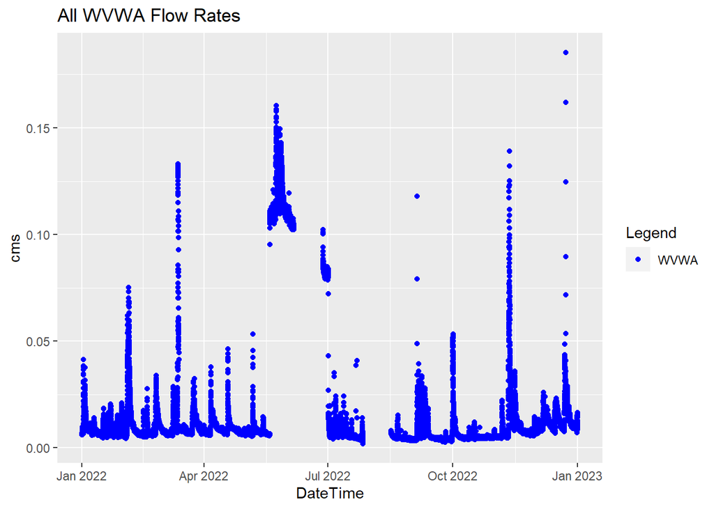

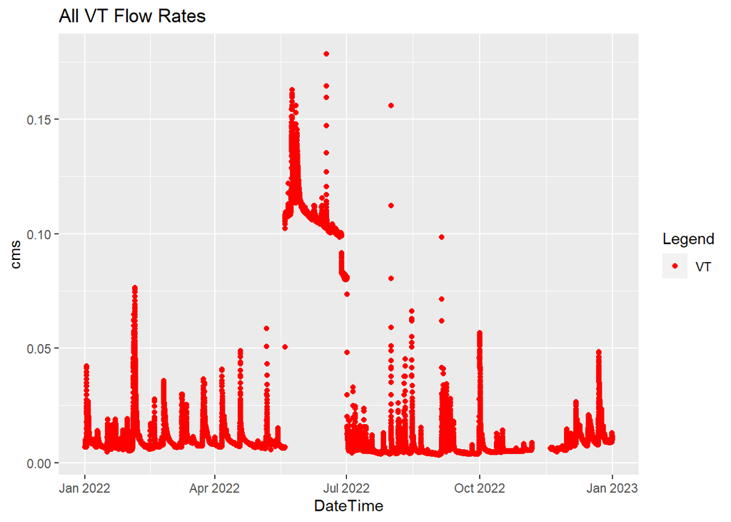

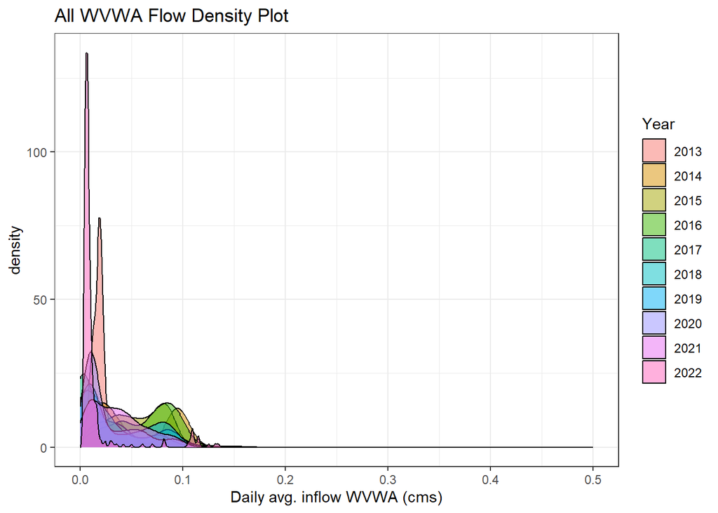

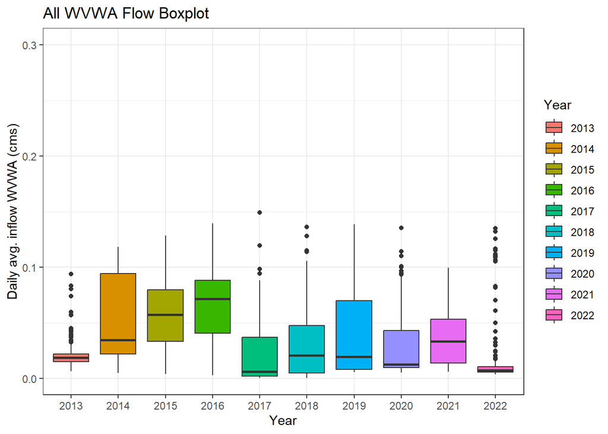

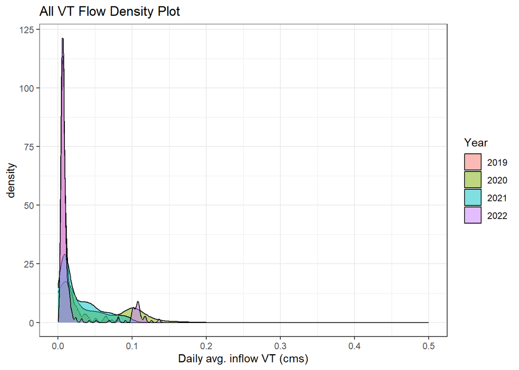

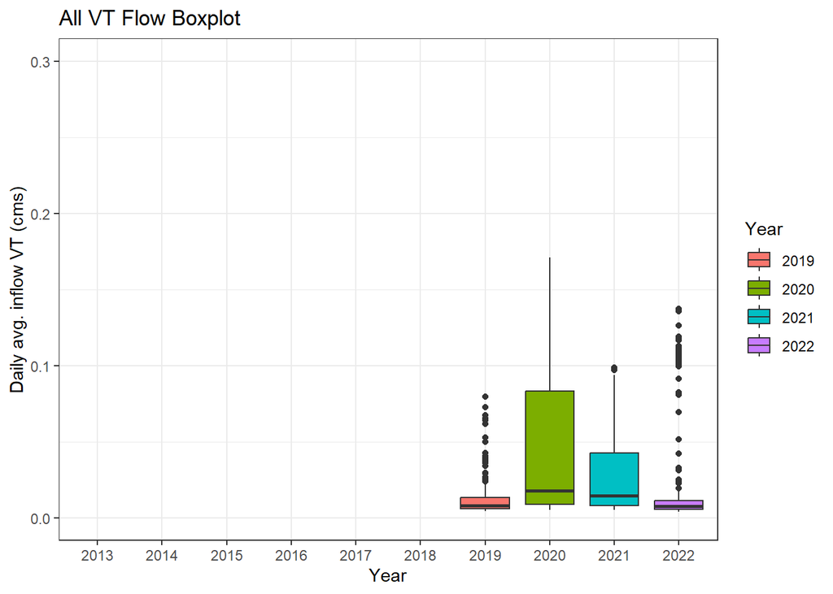

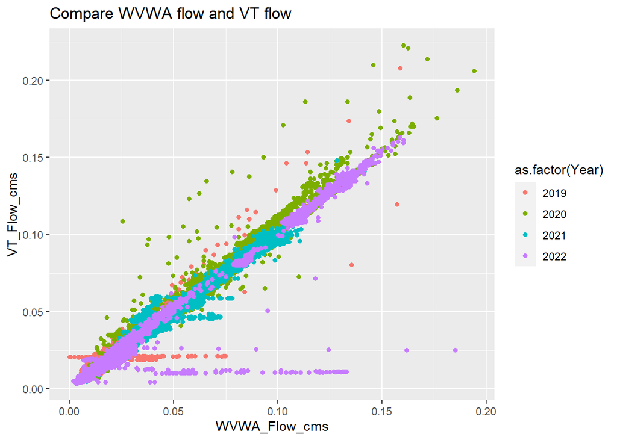

### Plots for WVWA_Pressure_psia

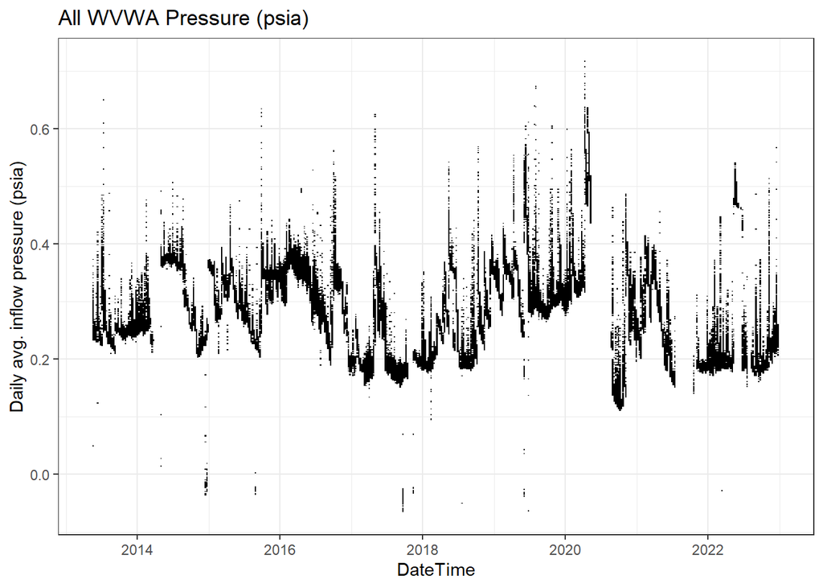

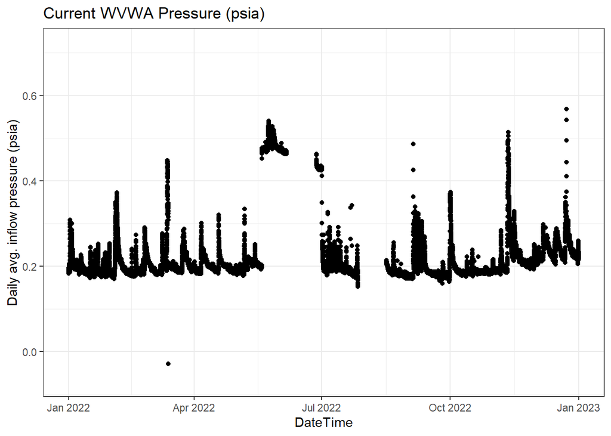

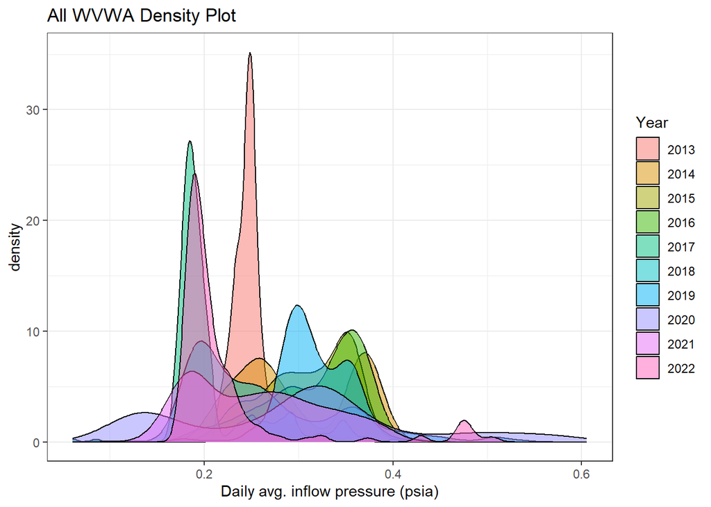

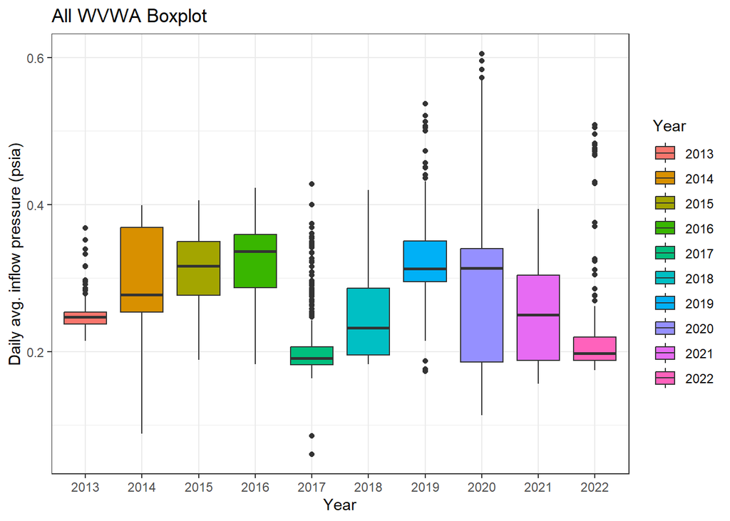

### Plots for WVWA_Pressure_psi

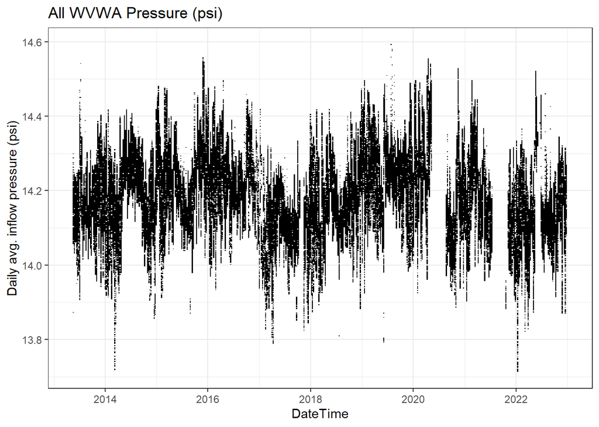

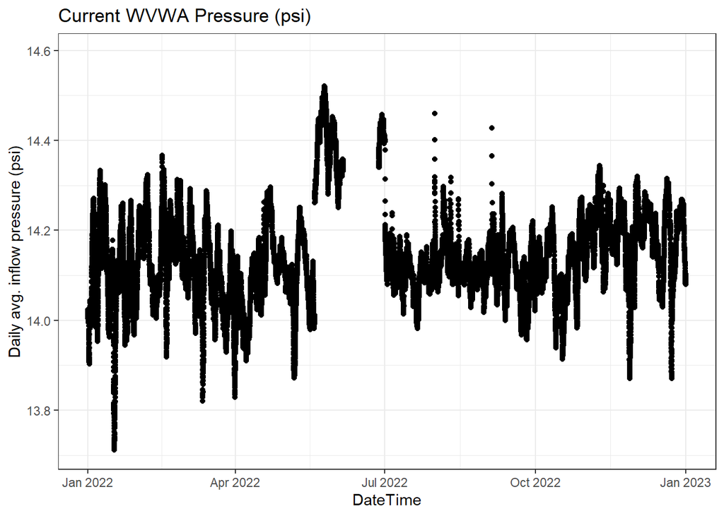

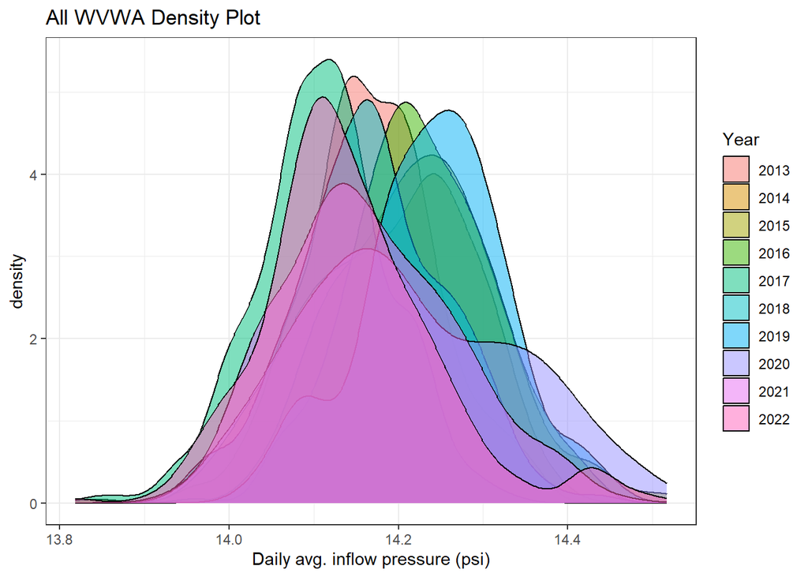

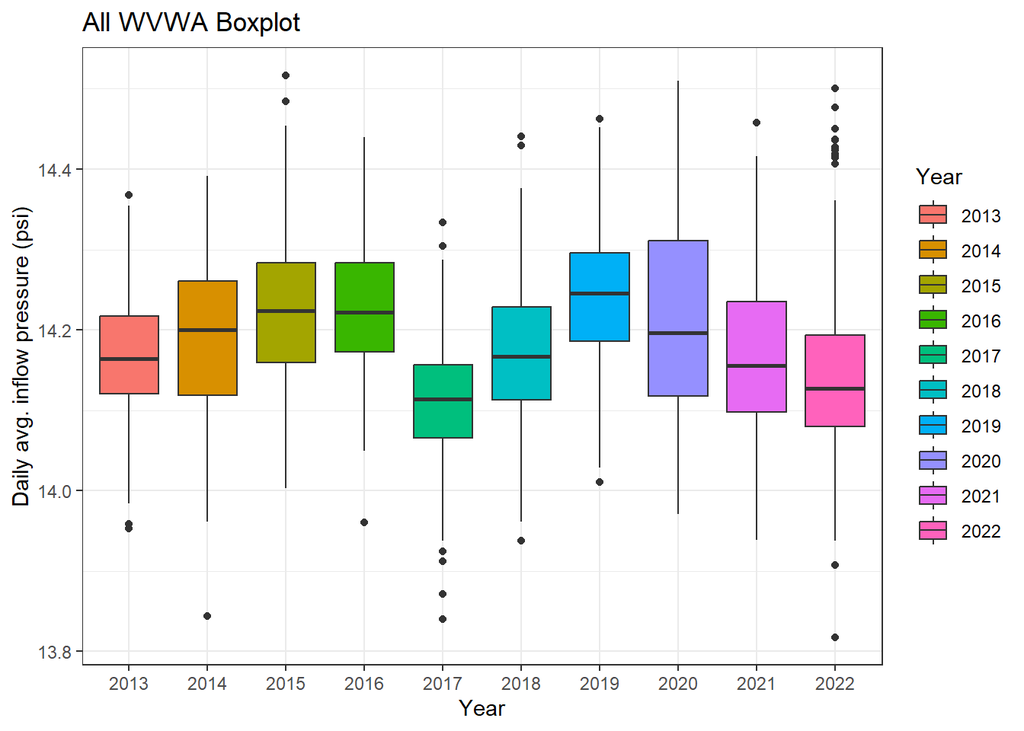

### Plots of raw pressure data from catwalk transducer

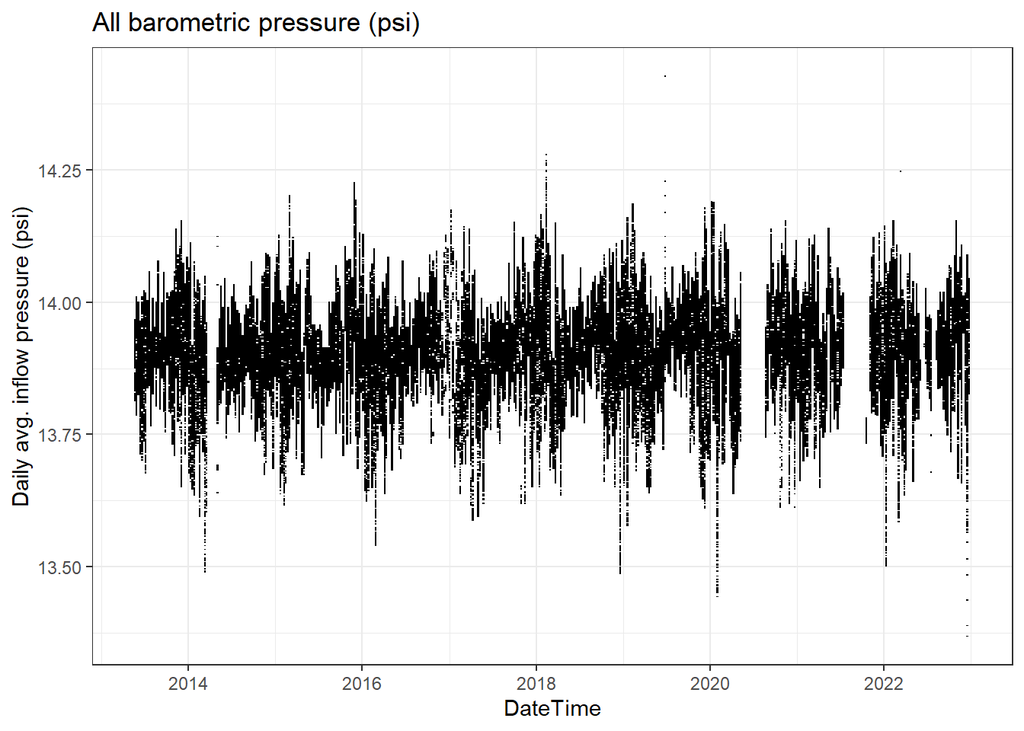

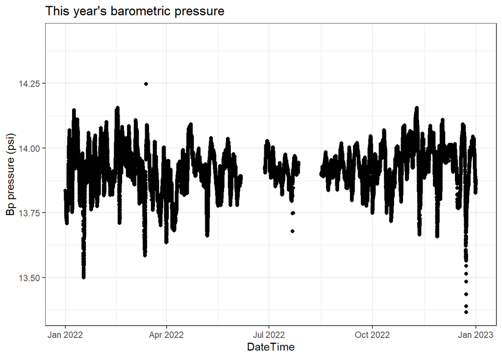

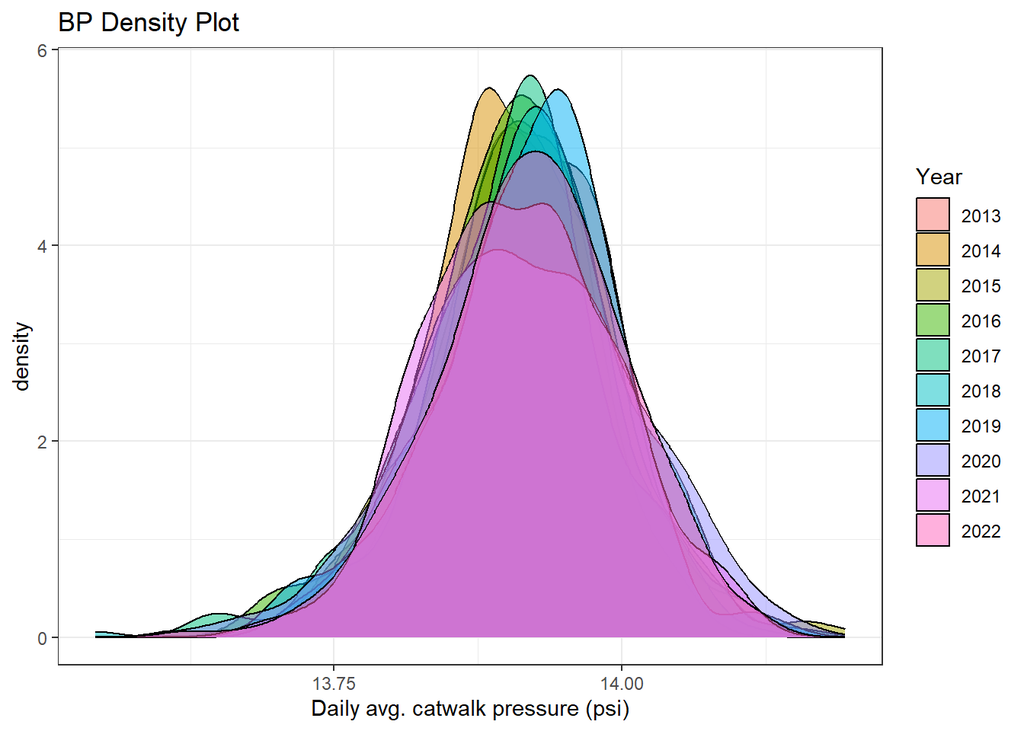

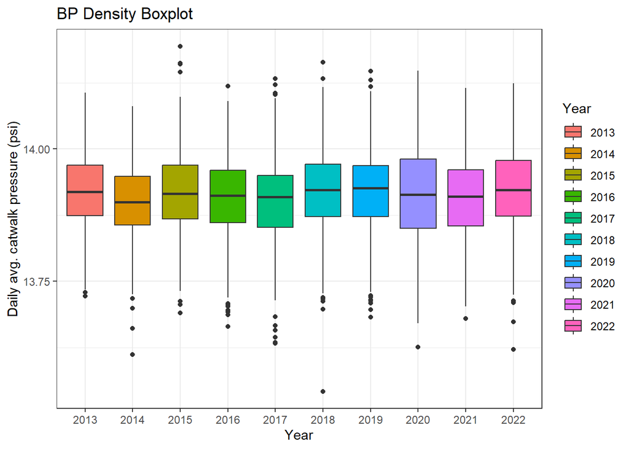

### Plots for VT pressure sensor readings

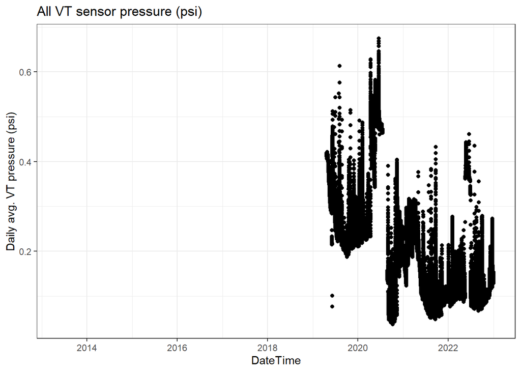

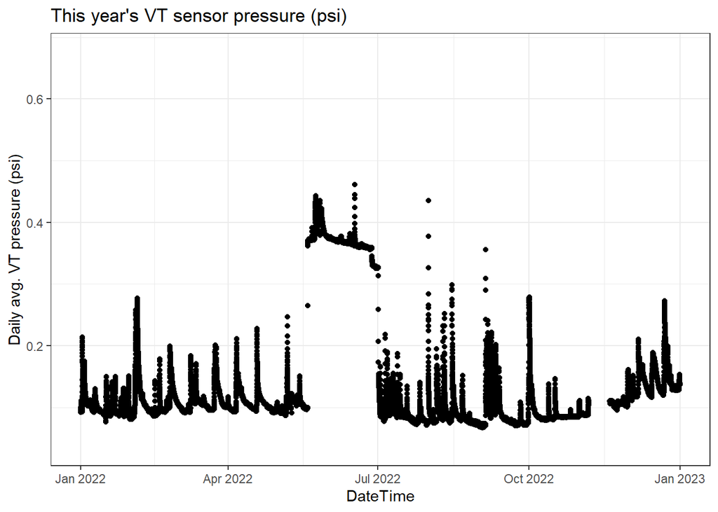

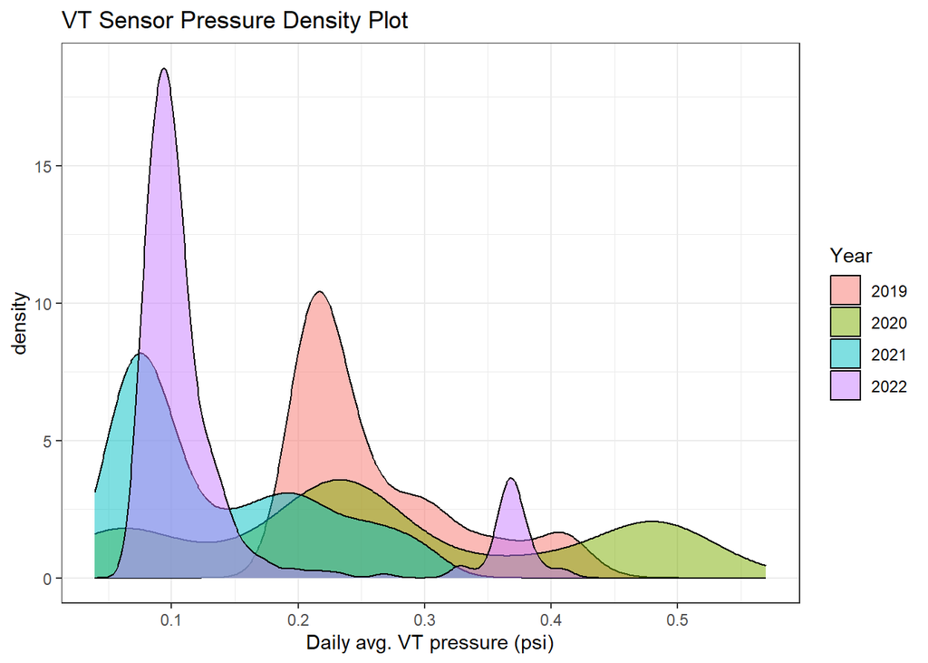

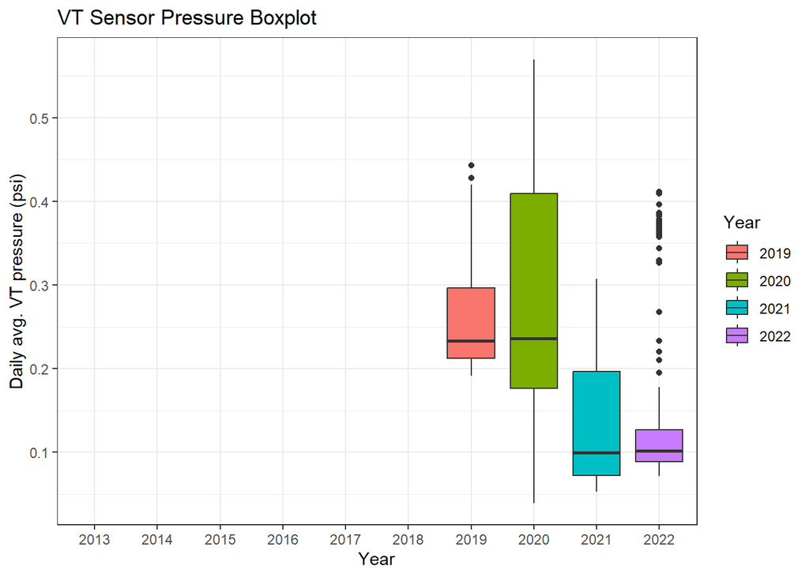

### Visualize Temperature Data

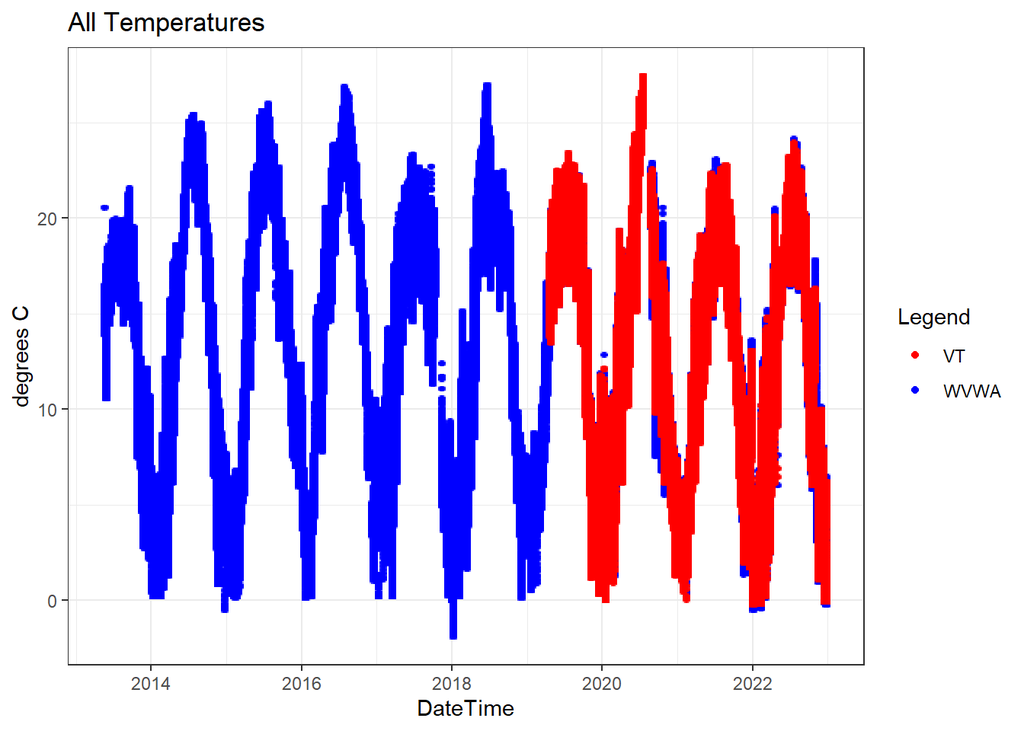

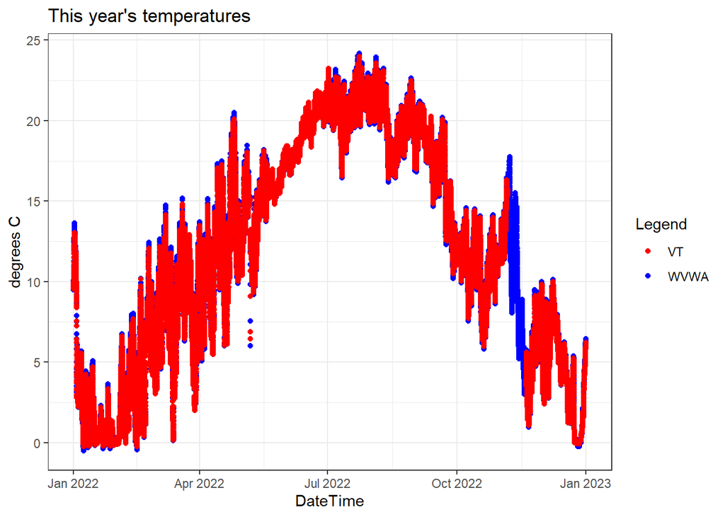

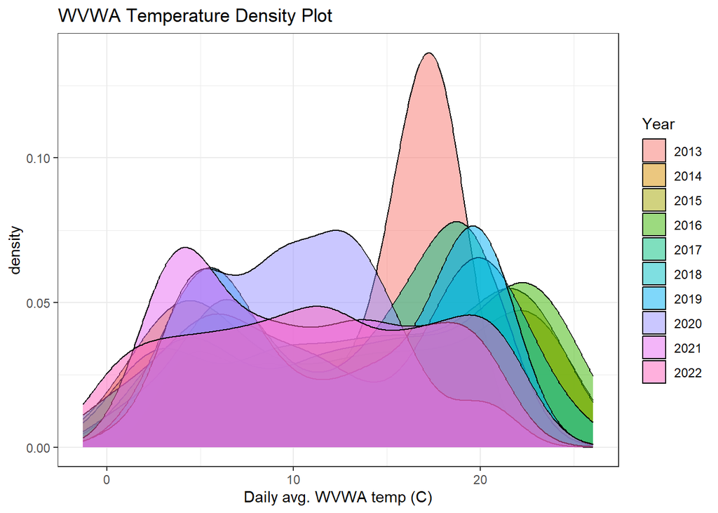

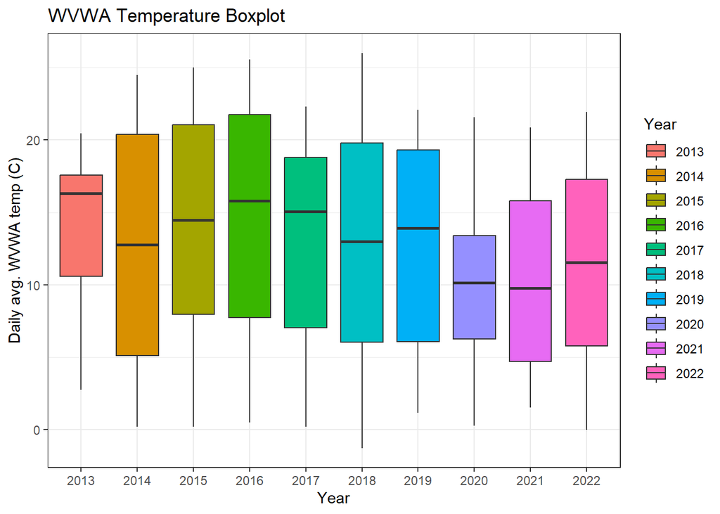

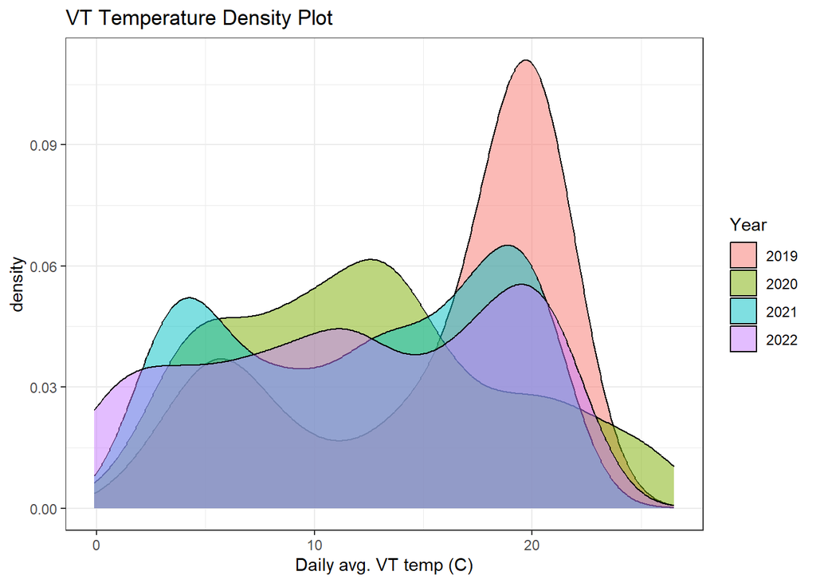

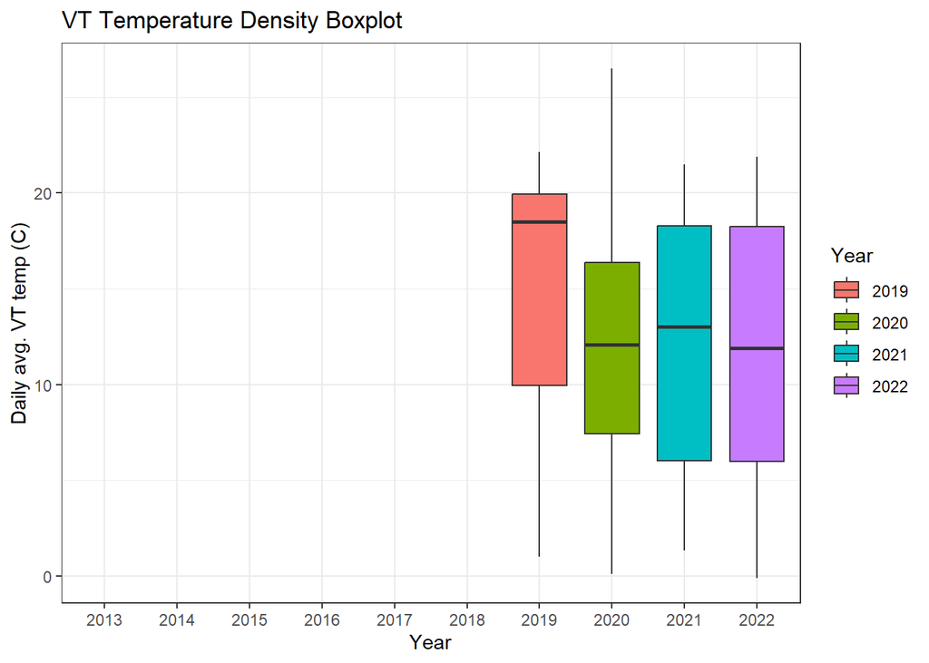

### Check new data file to the one from 2022

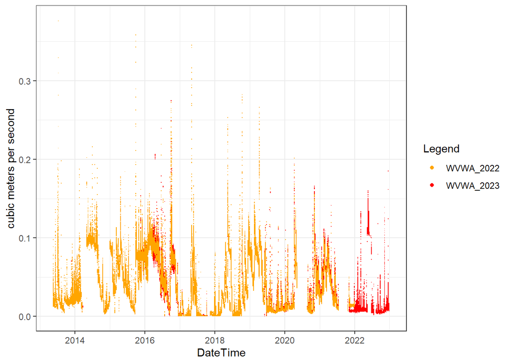

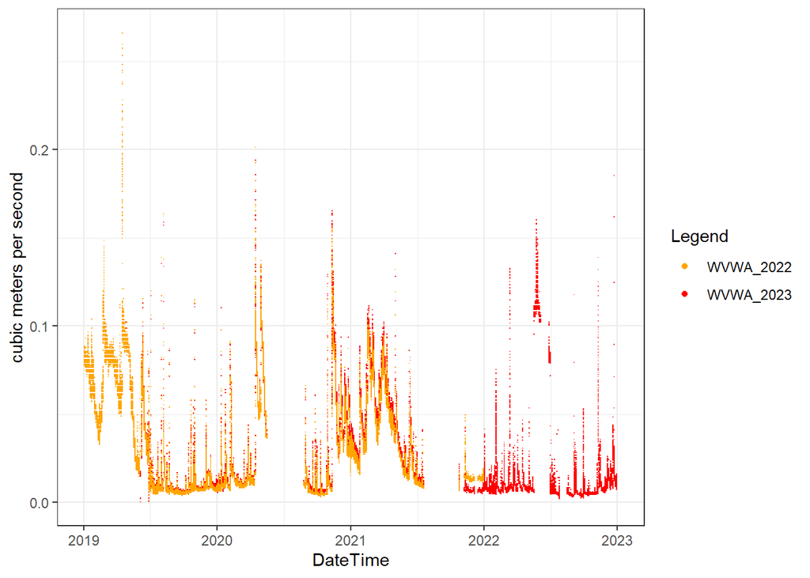

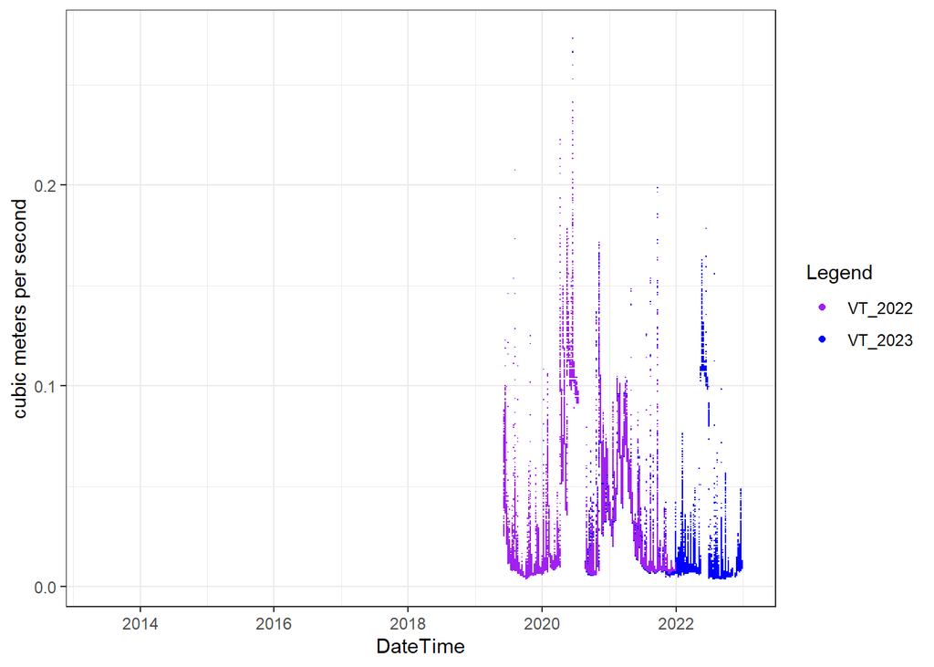

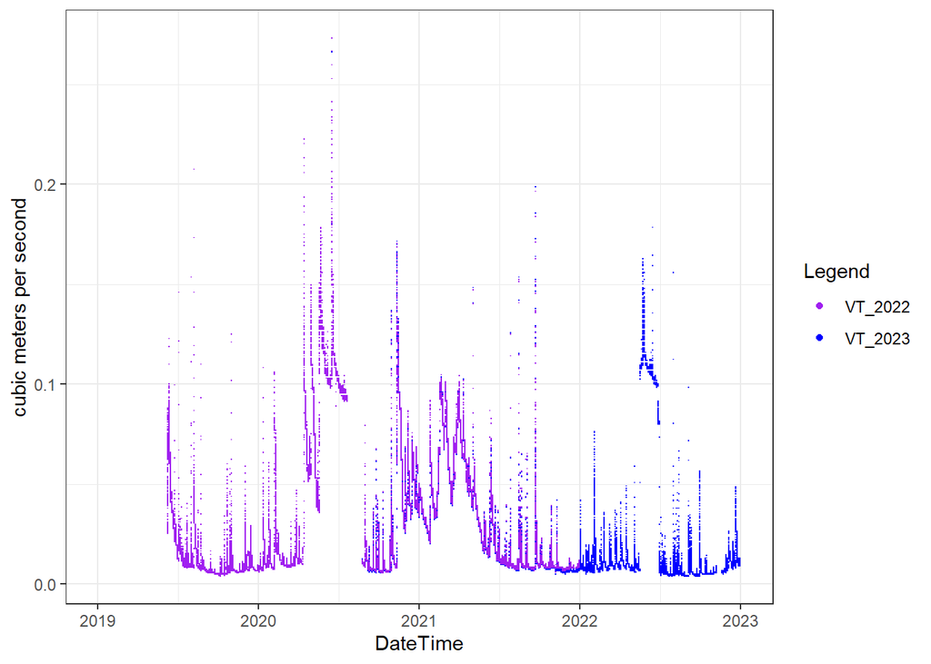